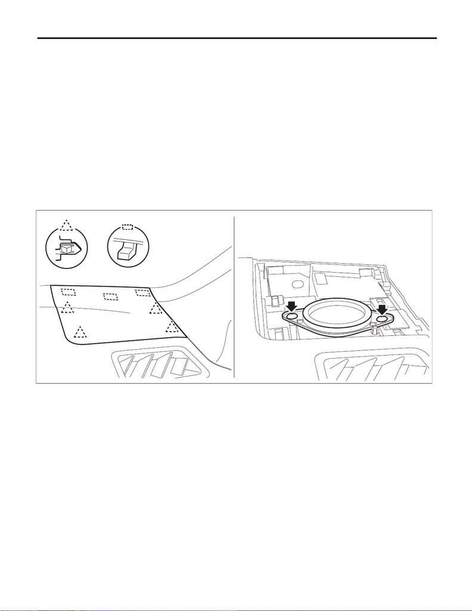

ET-9

Front Speaker

ENTERTAINMENT

6. Front Speaker

A: REMOVAL

1. TWEETER

1) Disconnect the ground cable from battery. <Ref. to NT-5, BATTERY, NOTE, Note.>

NOTE:

For models other than STI model, disconnect the ground terminal from battery sensor.

2) Remove the speaker assembly - tweeter.

(1) Release the clips and claws, then detach the grille speaker side.

NOTE:

Remove the grille speaker side by using a plastic remover.

(2) Remove the screws.

Preparation tool:

Stubby screwdriver

(3) Disconnect the connector and remove the speaker assembly - tweeter.

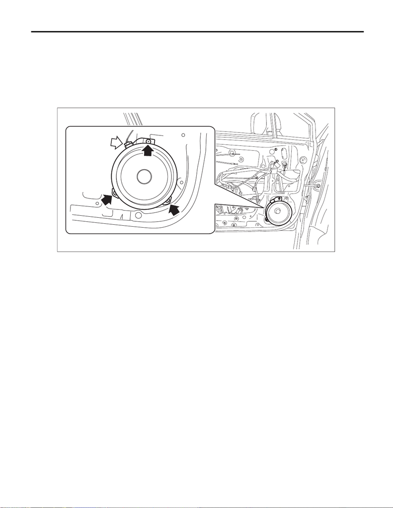

Front Speaker

ENTERTAINMENT

2. DOOR SPEAKER

1) Disconnect the ground cable from battery. <Ref. to NT-5, BATTERY, NOTE, Note.>

NOTE:

For models other than STI model, disconnect the ground terminal from battery sensor.

2) Remove the trim panel - front door. <Ref. to EI-56, FRONT DOOR, REMOVAL, Door Trim.>

3) Remove the front door speaker assembly.

(1) Remove the screws.

(2) Disconnect the connector, and remove the front door speaker assembly.

B: INSTALLATION

1. TWEETER

1) Install the speaker assembly - tweeter.

2) Connect the battery ground terminal. <Ref. to NT-5, BATTERY, NOTE, Note.>

NOTE:

For models other than STI model, connect the ground terminal to battery sensor.

2. DOOR SPEAKER

1) Install the front door speaker assembly.

2) Install the trim panel - front door.

3) Connect the battery ground terminal. <Ref. to NT-5, BATTERY, NOTE, Note.>

NOTE:

For models other than STI model, connect the ground terminal to battery sensor.

ET-00704